# DigiKat Map 3: Emotional Structure

Mapping Sentiment and Controversy in Croatian Catholic Digital Media

Author

DigiKat Project

Published

January 27, 2026

# 1 Introduction

This document presents **Map 3 of the DigiKat project**, analyzing the emotional structure of Croatian Catholic digital media. The core question driving this analysis is **What emotional register characterizes Croatian Catholic digital communication, and where does controversy emerge?**

## 1.1 Methodological Overview

**Sentiment analysis** classifies text into positive, neutral, or negative categories based on the emotional tone of the language used. This automated classification (AUTO_SENTIMENT in the data) provides a high level view of emotional valence across the corpus.

**Facebook reactions** offer a more granular view of audience emotional response. Unlike simple likes, reactions (LOVE, WOW, HAHA, SAD, ANGRY) capture distinct emotional states, enabling us to construct emotional fingerprints for different actors and content types.

**Key metrics in this analysis:**

| Metric | Definition | Interpretation |
| --- | --- | --- |
| Sentiment ratio | Positive posts / Negative posts | Higher values indicate more positive tone |
| LOVE share | LOVE reactions / Total emotional reactions | Measures affection/appreciation response |
| ANGRY share | ANGRY reactions / Total emotional reactions | Measures anger/outrage response |
| Controversy Index | (ANGRY / Interactions) x log(Interactions) | Combines anger intensity with reach |

**Interpretation guidance:**

- High LOVE share with low ANGRY share indicates devotional, well received content
- High ANGRY share may indicate controversial topics or provocative framing
- Controversy Index accounts for both intensity (ANGRY ratio) and visibility (interaction volume)
- Differences between automated sentiment and audience reactions reveal gaps between intent and reception

```r
dta <- readRDS("C:/Users/lsikic/Luka C/HKS/Projekti/Digitalni Kat/SHKM/DigiKat/data/merged_comprehensive.rds") %>%
  filter(SOURCE_TYPE != "tiktok", !is.na(SOURCE_TYPE)) %>%
  filter(DATE >= as.Date("2021-01-01") & DATE <= as.Date("2025-12-31")) %>%
  filter(year >= 2021 & year <= 2025)

setDT(dta)

# Check data loaded
cat("Data loaded:", nrow(dta), "rows\n")
```

```
Data loaded: 608879 rows
```

```r
if (nrow(dta) == 0) stop("No data after filtering! Check your date filters.")

n_posts <- nrow(dta)
n_sources <- uniqueN(dta$FROM)
date_range <- paste(min(dta$DATE), "to", max(dta$DATE))
```

```r
# =============================================================================
# ACTOR CLASSIFICATION V4 - SYNCHRONIZED WITH MAP 1
# =============================================================================
# Uses hierarchical priority: manual overrides -> secular exclusions ->
# domain matching -> pattern matching -> lay influencer detection -> default
# =============================================================================

# MANUAL OVERRIDES: Highest priority explicit classifications
manual_overrides <- list(
  "Institutional Official" = c(
    "hrvatska katolička mreža", "hrvatska katolicka mreza",
    "informativna katolička agencija", "informativna katolicka agencija",
    "hrvatski katolički radio", "hrvatski katolicki radio",
    "hrvatska biskupska konferencija", "ika", "hkr", "hkm", "hbk",
    "tiskovni ured hbk", "radio marija"
  ),
  "Independent Media" = c(
    "laudato tv", "laudatotv", "laudato.tv", "laudato.hr", "laudato",
    "bitno.net", "bitno net", "glas koncila", "glaskoncila",
    "nova eva", "nova-eva", "verbum", "totus tuus", "totus-tuus",
    "katolički tjednik", "katolicki tjednik", "kršćanska sadašnjost",
    "krscanska sadasnjost", "mir i dobro", "svjetlo riječi",
    "novizivot.net", "novi zivot", "novi život"
  ),
  "Charismatic Communities" = c(
    "božja pobjeda", "bozja pobjeda", "bozjapobjeda",
    "muževni budite", "muzevni budite", "muzevnibudite",
    "srce isusovo", "srceisuovo", "cenacolo", "comunità cenacolo",
    "duhovna obnova", "molitvena snaga",
    "dom molitve slavonski brod", "dom molitve",
    "molitvena zajednica sv. josipa"
  ),
  "Lay Influencers" = c(
    "katolička obitelj", "katolicka obitelj",
    "marija majka isusova", "božanske molitve", "bozanske molitve",
    "moćne molitve tv", "mocne molitve tv", "moćne molitve", "mocne molitve",
    "katoličke molitve", "katolicke molitve",
    "pulherissimus", "pod smokvom",
    "hrana za dušu", "hrana za dusu",
    "добровољци", "miletić marin", "miletic marin",
    "dijete vjere", "vjera",
    "kapljice ljubavi božje", "kapljice ljubavi bozje",
    "kršćanstvo", "krscanstvo",
    "jutarnja molitva duhu svetom", "blago molitve",
    "biblija krunice molitve",
    "molitve bogu",
    "vojnik sreće", "vojnik srece", "duhovne poruke i inspiracija",
    "kes duhovni kutak", "duhovni kutak",
    "molitve.hr", "duhovniportal.com", "duhovniportal"
  ),
  "Diocesan" = c(
    "zagrebačka nadbiskupija", "zagrebacka nadbiskupija",
    "sisačka biskupija", "sisacka biskupija",
    "župa šurkovac", "zupa surkovac", "sveta mati slobode",
    "župa sv. ilije proroka metković", "zupa sv. ilije proroka metkovic",
    "župa uznesenja bdm", "zupa uznesenja bdm", "župa uznesenja bdm - stenjevec",
    "šibenska biskupija", "sibenska biskupija",
    "požeška biskupija", "pozeskа biskupija",
    "dubrovacka biskupija", "dubrovačka biskupija",
    "dubrovacka-biskupija.hr",
    "zupa tramosnica", "župa tramošnica",
    "župa sv. vida", "zupa sv. vida", "župa sv. vida - petruševec"
  ),
  "Youth Organizations" = c(
    "susret hrvatske katoličke mladeži", "susret hrvatske katolicke mladezi",
    "shkm požega", "shkm pozega"
  ),
  "Academic" = c(
    "hrvatsko katoličko sveučilište", "hrvatsko katolicko sveuciliste",
    "universitas studiorum catholica croatica"
  )
)

# SECULAR MEDIA EXCLUSIONS: Always classify as Other
secular_exclusions <- c(
  # National portals (with and without .hr)
  "slobodnadalmacija", "slobodnadalmacija.hr",
  "vecernji", "vecernji.hr",
  "index.hr", "index",
  "jutarnji", "jutarnji.hr",
  "novilist", "novilist.hr",
  "24sata", "24sata.hr",
  "direktno", "direktno.hr",
  "nacional", "nacional.hr",
  "tportal", "tportal.hr",
  "dnevnik.hr", "dnevnik",
  "hrt.hr", "hrt",
  "n1info", "n1info.hr", "n1",
  "rtl.hr", "rtl",
  "net.hr",
  "telegram.hr", "telegram",
  "story.hr", "express.hr", "express", "advance.hr",
  # Regional portals
  "glasistre", "glasistre.hr",
  "dnevno.hr", "dnevno",
  "prigorski", "glas-slavonije", "glas slavonije",
  "croativ", "oluja.info",
  "maxportal", "maxportal.hr",
  "hkv.hr", "icv.hr", "novosti.hr", "7dnevno", "mnovine",
  "sjever.hr", "dulist.hr", "pozega.eu", "sibenik.in",
  "ferata.hr", "epodravina", "glasgacke", "radio-zlatar",
  "medjimurski.hr", "sbperiskop", "zagorje-international",
  "pozeski", "novine.hr", "dubrovnikinsider", "regionalni",
  "leportale", "varazdinske-vijesti", "radionasice",
  "brodportal", "ljportal", "dubrovnikportal", "01portal",
  "tomislavnews", "hia.com.hr", "portalnovosti", "antenazadar",
  "dalmacijanews", "zadarskilist", "medjimurjepress",
  "zagreb.info", "034portal", "057info", "cityportal",
  "klikaj.hr", "lika-online", "ploce.com", "sbonline",
  "narod.hr", "infokiosk", "hrsvijet", "tomislavcity",
  "vrisak.info", "dalmacijadanas", "dalmacijadanas.hr",
  "morski.hr", "zagreb.hr", "osijek031", "rijeka.hr", "zadar.hr",
  "zupanjac.net", "zupanjac",
  "dalmatinskiportal.hr", "dalmatinskiportal",
  "campaign-archive.com",
  # Forums and aggregators
  "forum.hr", "reddit", "anonymous_user", "komentari", "bug.hr",
  # Entertainment and other
  "inmemoriam", "magicus.info", "book.hr", "mojzagreb.info",
  "skole.hr", "tvprofil", "priznajem.hr", "dragovoljac.com",
  "croatia", "wikipedia",
  "facebook.com", "youtube.com", "instagram.com", "twitter.com",
  # Government and administrative
  "županija", "zupanija", "grad ", "opcina", "općina",
  # Non-Catholic religious groups
  "kršćanska proročka crkva", "krscanska prorocka crkva",
  "crkva svemogućeg boga", "crkva svemoguceg boga",
  "jehovini svjedoci", "adventisti", "baptisti", "pentekostalna",
  # Political parties
  "domovinski pokret", "hdz", "sdp", "most", "možemo", "mozemo"
)

classify_actor_v4 <- function(from_value, url_value = NA, platform_value = NA) {
  from_lower <- tolower(from_value)
  url_lower <- tolower(ifelse(is.na(url_value), "", url_value))
  platform_lower <- tolower(ifelse(is.na(platform_value), "", platform_value))
  combined <- paste(from_lower, url_lower)

  # Helper function for matching

  match_any <- function(patterns, text) {
    any(sapply(patterns, function(p) grepl(p, text, fixed = TRUE)))
  }

  # PRIORITY 1: Manual overrides (highest priority)
  for (actor_type in names(manual_overrides)) {
    if (match_any(manual_overrides[[actor_type]], from_lower)) {
      return(actor_type)
    }
  }

  # PRIORITY 2: Secular exclusions
  if (match_any(secular_exclusions, combined)) {
    return("Other")
  }

  # PRIORITY 3: Domain-based classification
  institutional_domains <- c("hkm.hr", "ika.hkm.hr", "hkr.hkm.hr", "hbk.hr")
  if (any(sapply(institutional_domains, function(x) grepl(x, url_lower, fixed = TRUE)))) {
    return("Institutional Official")
  }

  diocesan_domains <- c(
    "zg-nadbiskupija.hr", "biskupija-varazdinska.hr", "djos.hr",
    "biskupija-sj.hr", "rzs.hr", "rkc-sisak.hr", "zadarskanadbiskupija.hr",
    "gospicko-senjska-biskupija.hr", "nadbiskupija-split.com",
    "dubrovacka-biskupija.hr", "porec-biskupija.hr", "biskupija-kk.hr"
  )
  if (any(sapply(diocesan_domains, function(x) grepl(x, url_lower, fixed = TRUE)))) {
    return("Diocesan")
  }

  independent_media_domains <- c(
    "laudato.hr", "laudato.tv", "bitno.net", "glaskoncila.hr",
    "nova-eva.com", "verbum.hr", "ks.hr", "novizivot.net"
  )
  if (any(sapply(independent_media_domains, function(x) grepl(x, url_lower, fixed = TRUE)))) {
    return("Independent Media")
  }

  # PRIORITY 4: Pattern-based classification

  # Check for parish patterns (covers missing diacritics)
  is_parish <- grepl("^župa|^zupa|župi|zupi|- župa|- zupa", from_lower, ignore.case = TRUE) ||
               grepl("parish", from_lower, ignore.case = TRUE)

  diocesan_names <- c("nadbiskupija", "biskupija")
  if (is_parish || any(sapply(diocesan_names, function(x) grepl(x, from_lower, fixed = TRUE)))) {
    return("Diocesan")
  }

  # Religious orders
  religious_orders <- c(
    "franjevci", "franjevački", "franjevacki", "ofm",
    "isusovci", "družba isusova", "druzba isusova",
    "dominikanci", "dominikanski",
    "salezijanci", "salezijanski", "sdb",
    "karmelićani", "karmelicani", "karmel",
    "benediktinci", "benediktinski", "osb",
    "kapucini", "kapucinski", "ofmcap",
    "pavlini", "pavlinski", "trapisti", "cisterciti",
    "sestre milosrdnice", "uršulinke", "klarise",
    "službenice milosrđa", "kćeri božje ljubavi", "kceri bozje ljubavi"
  )
  if (any(sapply(religious_orders, function(x) grepl(x, from_lower, fixed = TRUE)))) {
    return("Religious Orders")
  }

  # Charismatic communities
  charismatic <- c(
    "molitvena zajednica", "karizmatska", "cenacolo",
    "emmanuel community", "emmanuel zajednica", "taize",
    "neokatekumenski", "neokatekumenska", "kursiljo",
    "fokolari", "fokolarini", "komunija i oslobođenje",
    "dom molitve", "kuća molitve", "kuca molitve"
  )
  if (any(sapply(charismatic, function(x) grepl(x, from_lower, fixed = TRUE)))) {
    return("Charismatic Communities")
  }

  # Individual priests (check prefix at start of name)
  priest_prefixes <- c("fra ", "don ", "vlč.", "vlc.", "msgr.", "mons.",
                       "o. ", "pater ", "preč.", "prec.")
  for (prefix in priest_prefixes) {
    if (startsWith(from_lower, prefix)) return("Individual Priests")
  }
  if (grepl("svećenik|svecenik|župnik|zupnik", from_lower)) {
    return("Individual Priests")
  }

  # Youth organizations
  youth <- c(
    "frama", "shkm", "katolička mladež", "katolicka mladez",
    "ministranti", "mladifra", "mladi fra", "kaem",
    "sveučilišna kapelanija", "studentska kapelanija"
  )
  if (any(sapply(youth, function(x) grepl(x, from_lower, fixed = TRUE)))) {
    return("Youth Organizations")
  }

  # Academic
  academic <- c(
    "unicath", "katolički bogoslovni fakultet", "kbf",
    "teologija", "filozofski fakultet družbe isusove", "hks.hr",
    "hrvatsko katoličko sveučilište", "hku"
  )
  if (any(sapply(academic, function(x) grepl(x, from_lower, fixed = TRUE)))) {
    return("Academic")
  }

  # PRIORITY 5: Lay influencer detection (platform-aware)
  lay_keywords <- c(
    "vjera", "molitva", "molitve", "isus", "krist", "gospa", "marija",
    "duhovnost", "duhovna", "duhovni", "biblija", "psalm", "blagoslov",
    "krunica", "rozarij", "katolička obitelj", "evanđelje", "evandelje"
  )

  lay_exclude <- c(".hr", ".net", ".com", "portal", "vijesti", "news", "radio")

  is_likely_social <- platform_lower %in% c("facebook", "instagram", "youtube", "twitter") ||
                      !grepl("\\.[a-z]{2,4}$", from_lower)

  has_devotional <- any(sapply(lay_keywords, function(x) grepl(x, from_lower, fixed = TRUE)))
  has_media_marker <- any(sapply(lay_exclude, function(x) grepl(x, from_lower, fixed = TRUE)))

  if (is_likely_social && has_devotional && !has_media_marker) {
    return("Lay Influencers")
  }

  return("Other")
}

# Apply classification
dta[, ACTOR_TYPE := mapply(classify_actor_v4, FROM, URL, SOURCE_TYPE)]

# Verify classification
cat("ACTOR_TYPE class:", class(dta$ACTOR_TYPE), "\n")
```

```
ACTOR_TYPE class: character
```

```r
cat("ACTOR_TYPE distribution:\n")
```

```
ACTOR_TYPE distribution:
```

```r
print(table(dta$ACTOR_TYPE))
```

```
               Academic Charismatic Communities                Diocesan
                    671                    1282                   13841
      Independent Media  Institutional Official         Lay Influencers
                  31401                   62744                   28451
                  Other        Religious Orders     Youth Organizations
                 468760                    1677                      52
```

## 1.2 Corpus Overview

```r
tibble(
  Metric = c("Total posts", "Unique sources", "Date range", "Platforms",
             "Posts with sentiment", "Posts with Facebook reactions"),
  Value = c(
    format(n_posts, big.mark = ","),
    format(n_sources, big.mark = ","),
    date_range,
    paste(unique(dta$SOURCE_TYPE), collapse = ", "),
    format(sum(!is.na(dta$AUTO_SENTIMENT)), big.mark = ","),
    format(sum(dta$SOURCE_TYPE == "facebook" & !is.na(dta$LOVE_COUNT)), big.mark = ",")
  )
) %>%
  kable(col.names = c("Metric", "Value")) %>%
  kable_styling(bootstrap_options = c("striped", "hover"), full_width = FALSE)
```

| Metric | Value |
| --- | --- |
| Total posts | 608,879 |
| Unique sources | 16,426 |
| Date range | 2021-01-01 to 2025-12-31 |
| Platforms | web, facebook, twitter, comment, youtube, forum, reddit, instagram |
| Posts with sentiment | 608,879 |
| Posts with Facebook reactions | 68,771 |

# 2 Analysis 3.1: Sentiment Distribution

Sentiment analysis classifies each post as positive, neutral, or negative based on linguistic features. This section examines how sentiment varies across the corpus, platforms, and actor types.

**Reading the charts:**

- **Overall distribution** shows the baseline emotional tone of the corpus
- **Platform comparison** reveals how different media afford different emotional registers
- **Actor comparison** identifies which communicators tend toward more positive or negative framing
- **Positivity ratio** (positive/negative) summarizes relative emotional valence

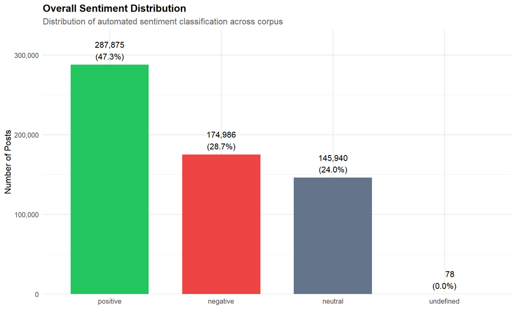

```r
sentiment_dist <- dta[!is.na(AUTO_SENTIMENT), .(
  Count = .N
), by = AUTO_SENTIMENT][order(-Count)]

sentiment_dist[, Percentage := Count / sum(Count) * 100]

ggplot(sentiment_dist, aes(x = reorder(AUTO_SENTIMENT, -Count), y = Count, fill = AUTO_SENTIMENT)) +
  geom_col(width = 0.7) +
  geom_text(aes(label = sprintf("%s\n(%.1f%%)", format(Count, big.mark = ","), Percentage)),
            vjust = -0.3, size = 4) +
  scale_fill_manual(values = sentiment_colors) +
  scale_y_continuous(labels = comma, expand = expansion(mult = c(0, 0.15))) +
  labs(
    title = "Overall Sentiment Distribution",
    subtitle = "Distribution of automated sentiment classification across corpus",
    x = NULL,
    y = "Number of Posts"
  ) +
  theme(legend.position = "none")
```

## 2.1 Sentiment by Platform

Different platforms may encourage different emotional registers due to their affordances, audience expectations, and content formats.

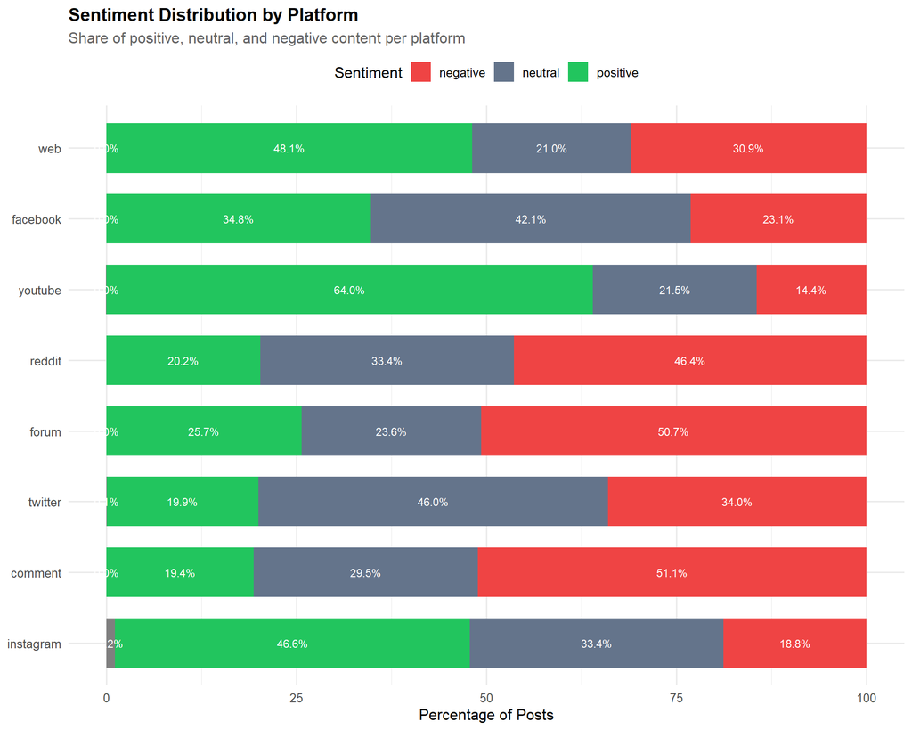

```r
sentiment_platform <- dta[!is.na(AUTO_SENTIMENT), .(
  Count = .N
), by = .(SOURCE_TYPE, AUTO_SENTIMENT)]

sentiment_platform[, Total := sum(Count), by = SOURCE_TYPE]
sentiment_platform[, Percentage := Count / Total * 100]

ggplot(sentiment_platform, aes(x = reorder(SOURCE_TYPE, Total), y = Percentage, fill = AUTO_SENTIMENT)) +
  geom_col(position = "stack", width = 0.7) +
  geom_text(aes(label = sprintf("%.1f%%", Percentage)),
            position = position_stack(vjust = 0.5),
            size = 3, color = "white") +
  coord_flip() +
  scale_fill_manual(values = sentiment_colors) +
  labs(
    title = "Sentiment Distribution by Platform",
    subtitle = "Share of positive, neutral, and negative content per platform",
    x = NULL,
    y = "Percentage of Posts",
    fill = "Sentiment"
  ) +
  theme(legend.position = "top")
```

## 2.2 Sentiment by Actor Type

Actor types may have characteristic emotional registers reflecting their institutional roles, communication strategies, and target audiences.

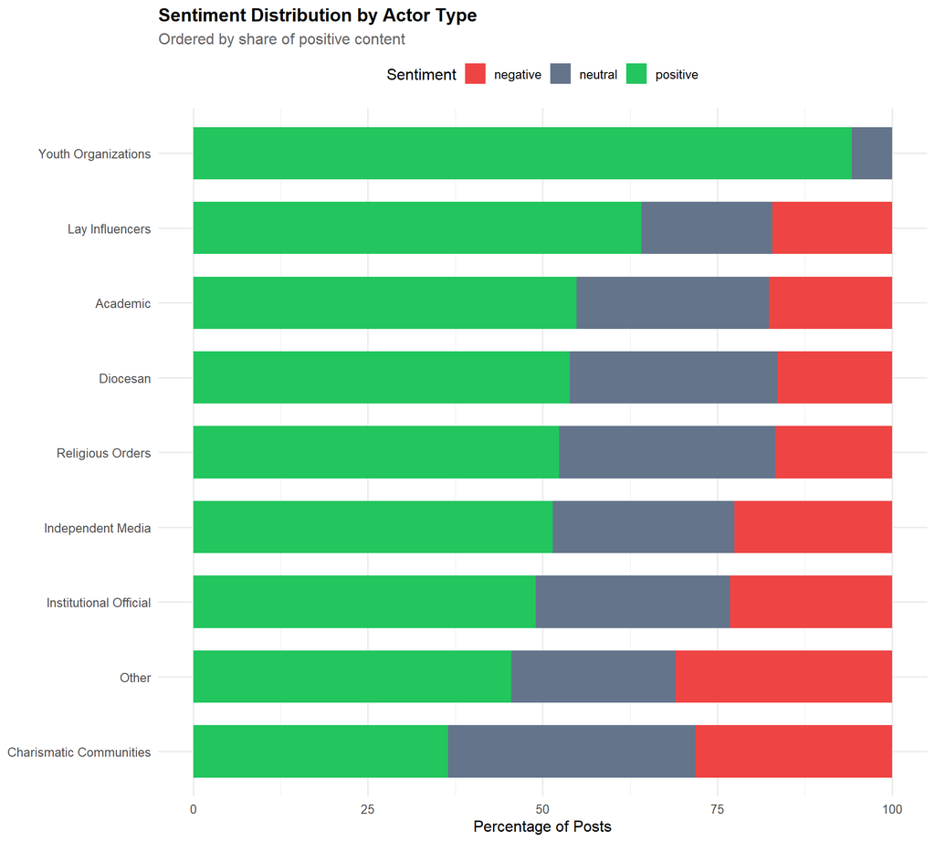

```r
sentiment_actor <- dta[!is.na(AUTO_SENTIMENT), .(
  Count = .N
), by = .(ACTOR_TYPE, AUTO_SENTIMENT)]

sentiment_actor[, Total := sum(Count), by = ACTOR_TYPE]
sentiment_actor[, Percentage := Count / Total * 100]

actor_order <- sentiment_actor[AUTO_SENTIMENT == "positive"][order(-Percentage)]$ACTOR_TYPE

ggplot(sentiment_actor, aes(x = factor(ACTOR_TYPE, levels = rev(actor_order)),
                            y = Percentage, fill = AUTO_SENTIMENT)) +
  geom_col(position = "stack", width = 0.7) +
  coord_flip() +
  scale_fill_manual(values = sentiment_colors) +
  labs(
    title = "Sentiment Distribution by Actor Type",
    subtitle = "Ordered by share of positive content",
    x = NULL,
    y = "Percentage of Posts",
    fill = "Sentiment"
  ) +
  theme(legend.position = "top")
```

## 2.3 Sentiment Summary Table

The **Positivity Ratio** divides positive posts by negative posts. Values above 1 indicate more positive than negative content; higher values indicate a more positive overall tone.

```r
sentiment_summary <- dta[!is.na(AUTO_SENTIMENT), .(
  Total_Posts = .N,
  Positive = sum(AUTO_SENTIMENT == "positive"),
  Neutral = sum(AUTO_SENTIMENT == "neutral"),
  Negative = sum(AUTO_SENTIMENT == "negative")
), by = ACTOR_TYPE]

sentiment_summary[, `:=`(
  Positive_Pct = Positive / Total_Posts * 100,
  Neutral_Pct = Neutral / Total_Posts * 100,
  Negative_Pct = Negative / Total_Posts * 100,
  Positivity_Ratio = Positive / (Negative + 0.1)
)]

sentiment_summary[order(-Positive_Pct)] %>%
  mutate(
    Total_Posts = format(Total_Posts, big.mark = ","),
    Positive_Pct = sprintf("%.1f%%", Positive_Pct),
    Neutral_Pct = sprintf("%.1f%%", Neutral_Pct),
    Negative_Pct = sprintf("%.1f%%", Negative_Pct),
    Positivity_Ratio = sprintf("%.2f", Positivity_Ratio)
  ) %>%
  select(ACTOR_TYPE, Total_Posts, Positive_Pct, Neutral_Pct, Negative_Pct, Positivity_Ratio) %>%
  kable(col.names = c("Actor Type", "Total Posts", "Positive %", "Neutral %",
                      "Negative %", "Positivity Ratio")) %>%
  kable_styling(bootstrap_options = c("striped", "hover"), full_width = FALSE)
```

| Actor Type | Total Posts | Positive % | Neutral % | Negative % | Positivity Ratio |
| --- | --- | --- | --- | --- | --- |
| Youth Organizations | 52 | 94.2% | 5.8% | 0.0% | 490.00 |
| Lay Influencers | 28,451 | 64.2% | 18.7% | 17.1% | 3.75 |
| Academic | 671 | 54.8% | 27.6% | 17.6% | 3.12 |
| Diocesan | 13,841 | 53.9% | 29.7% | 16.4% | 3.28 |
| Religious Orders | 1,677 | 52.4% | 30.9% | 16.7% | 3.13 |
| Independent Media | 31,401 | 51.4% | 26.0% | 22.6% | 2.28 |
| Institutional Official | 62,744 | 49.0% | 27.8% | 23.2% | 2.11 |
| Other | 468,760 | 45.5% | 23.4% | 31.0% | 1.47 |
| Charismatic Communities | 1,282 | 36.5% | 35.3% | 28.2% | 1.30 |

## 2.4 Sentiment and Engagement Relationship

Does emotional tone affect audience engagement? This analysis examines whether positive, neutral, or negative content generates different levels of interaction.

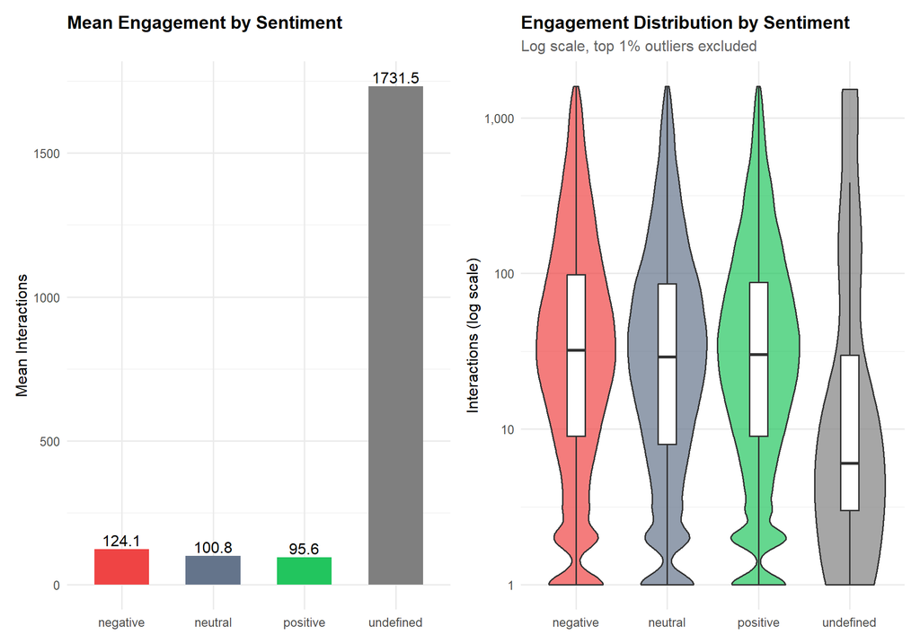

```r
sentiment_engagement <- dta[!is.na(AUTO_SENTIMENT) & !is.na(INTERACTIONS), .(
  Mean_Interactions = mean(INTERACTIONS, na.rm = TRUE),
  Median_Interactions = median(INTERACTIONS, na.rm = TRUE),
  Total_Interactions = sum(INTERACTIONS, na.rm = TRUE),
  Count = .N
), by = AUTO_SENTIMENT]

p1 <- ggplot(sentiment_engagement, aes(x = AUTO_SENTIMENT, y = Mean_Interactions, fill = AUTO_SENTIMENT)) +
  geom_col(width = 0.6) +
  geom_text(aes(label = sprintf("%.1f", Mean_Interactions)), vjust = -0.3) +
  scale_fill_manual(values = sentiment_colors) +
  labs(
    title = "Mean Engagement by Sentiment",
    x = NULL,
    y = "Mean Interactions"
  ) +
  theme(legend.position = "none")

p2 <- ggplot(dta[!is.na(AUTO_SENTIMENT) & INTERACTIONS > 0 & INTERACTIONS < quantile(INTERACTIONS, 0.99, na.rm = TRUE)],
             aes(x = AUTO_SENTIMENT, y = INTERACTIONS, fill = AUTO_SENTIMENT)) +
  geom_violin(alpha = 0.7) +
  geom_boxplot(width = 0.2, fill = "white", outlier.shape = NA) +
  scale_fill_manual(values = sentiment_colors) +
  scale_y_log10(labels = comma) +
  labs(
    title = "Engagement Distribution by Sentiment",
    subtitle = "Log scale, top 1% outliers excluded",
    x = NULL,
    y = "Interactions (log scale)"
  ) +
  theme(legend.position = "none")

p1 + p2
```

# 3 Analysis 3.2: Emotional Fingerprinting

Facebook reactions provide granular emotional data beyond simple sentiment. Each reaction type captures a distinct emotional response:

| Reaction | Emotional Meaning | Content Association |
| --- | --- | --- |
| LOVE | Deep affection, strong appreciation | Devotional, inspirational |
| WOW | Surprise, amazement | News, revelations |
| HAHA | Amusement, humor | Light content, satire |
| SAD | Sorrow, empathy | Death notices, suffering |
| ANGRY | Outrage, disagreement | Controversy, injustice |

By analyzing the mix of reactions each actor type receives, we can construct **emotional fingerprints** that characterize their audience relationships.

```r
fb_data <- dta[SOURCE_TYPE == "facebook" &
               !is.na(LOVE_COUNT) &
               !is.na(INTERACTIONS) &
               INTERACTIONS > 0]

cat("Facebook posts with reaction data:", nrow(fb_data), "\n")
```

```
Facebook posts with reaction data: 63843
```

```r
if (nrow(fb_data) > 0) {
  fb_data[, `:=`(
    LOVE_RATIO = LOVE_COUNT / INTERACTIONS,
    WOW_RATIO = fifelse(is.na(WOW_COUNT), 0, WOW_COUNT) / INTERACTIONS,
    HAHA_RATIO = fifelse(is.na(HAHA_COUNT), 0, HAHA_COUNT) / INTERACTIONS,
    SAD_RATIO = fifelse(is.na(SAD_COUNT), 0, SAD_COUNT) / INTERACTIONS,
    ANGRY_RATIO = fifelse(is.na(ANGRY_COUNT), 0, ANGRY_COUNT) / INTERACTIONS,
    LIKE_RATIO = LIKE_COUNT / INTERACTIONS
  )]

  fb_data[, Total_Reactions := fifelse(is.na(LOVE_COUNT), 0, LOVE_COUNT) +
                               fifelse(is.na(WOW_COUNT), 0, WOW_COUNT) +
                               fifelse(is.na(HAHA_COUNT), 0, HAHA_COUNT) +
                               fifelse(is.na(SAD_COUNT), 0, SAD_COUNT) +
                               fifelse(is.na(ANGRY_COUNT), 0, ANGRY_COUNT)]

  fb_data[Total_Reactions > 0, `:=`(
    LOVE_SHARE = LOVE_COUNT / Total_Reactions,
    WOW_SHARE = fifelse(is.na(WOW_COUNT), 0, WOW_COUNT) / Total_Reactions,
    HAHA_SHARE = fifelse(is.na(HAHA_COUNT), 0, HAHA_COUNT) / Total_Reactions,
    SAD_SHARE = fifelse(is.na(SAD_COUNT), 0, SAD_COUNT) / Total_Reactions,
    ANGRY_SHARE = fifelse(is.na(ANGRY_COUNT), 0, ANGRY_COUNT) / Total_Reactions
  )]
}
```

## 3.1 Overall Emotional Profile

The overall distribution of emotional reactions reveals the dominant emotional register of Croatian Catholic Facebook content.

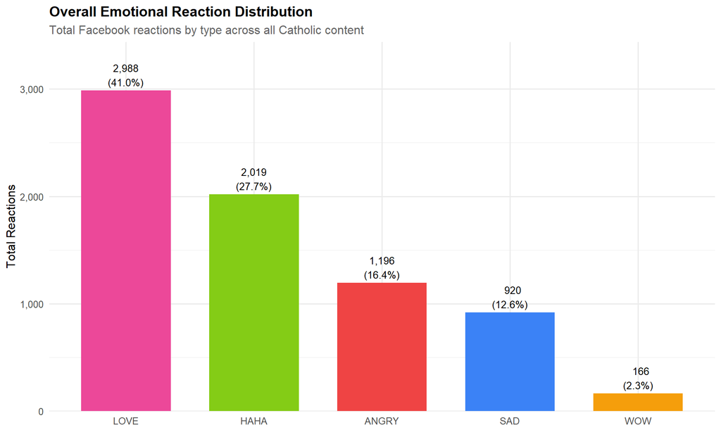

```r
if (nrow(fb_data) > 0) {
  emotion_totals <- data.table(
    Emotion = c("LOVE", "WOW", "HAHA", "SAD", "ANGRY"),
    Total = c(
      sum(fb_data$LOVE_COUNT, na.rm = TRUE),
      sum(fb_data$WOW_COUNT, na.rm = TRUE),
      sum(fb_data$HAHA_COUNT, na.rm = TRUE),
      sum(fb_data$SAD_COUNT, na.rm = TRUE),
      sum(fb_data$ANGRY_COUNT, na.rm = TRUE)
    )
  )

  emotion_totals[, Percentage := Total / sum(Total) * 100]

  ggplot(emotion_totals, aes(x = reorder(Emotion, -Total), y = Total, fill = Emotion)) +
    geom_col(width = 0.7) +
    geom_text(aes(label = sprintf("%s\n(%.1f%%)", format(Total, big.mark = ","), Percentage)),
              vjust = -0.2, size = 3.5) +
    scale_fill_manual(values = emotion_colors) +
    scale_y_continuous(labels = comma, expand = expansion(mult = c(0, 0.15))) +
    labs(
      title = "Overall Emotional Reaction Distribution",
      subtitle = "Total Facebook reactions by type across all Catholic content",
      x = NULL,
      y = "Total Reactions"
    ) +
    theme(legend.position = "none")
} else {
  cat("No Facebook reaction data available.\n")
}
```

## 3.2 Emotional Fingerprints by Actor Type

Each actor type has a characteristic mix of emotional reactions. These fingerprints reveal how audiences emotionally engage with different types of Catholic communicators.

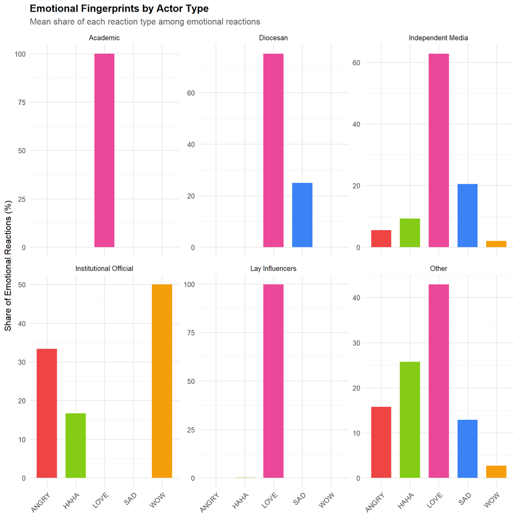

```r
if (nrow(fb_data) > 0 && sum(fb_data$Total_Reactions > 0, na.rm = TRUE) > 0) {
  actor_emotions <- fb_data[Total_Reactions > 0, .(
    LOVE = mean(LOVE_SHARE, na.rm = TRUE) * 100,
    WOW = mean(WOW_SHARE, na.rm = TRUE) * 100,
    HAHA = mean(HAHA_SHARE, na.rm = TRUE) * 100,
    SAD = mean(SAD_SHARE, na.rm = TRUE) * 100,
    ANGRY = mean(ANGRY_SHARE, na.rm = TRUE) * 100,
    Posts = .N
  ), by = ACTOR_TYPE]

  actor_emotions_long <- actor_emotions %>%
    select(-Posts) %>%
    pivot_longer(cols = -ACTOR_TYPE, names_to = "Emotion", values_to = "Share")

  ggplot(actor_emotions_long, aes(x = Emotion, y = Share, fill = Emotion)) +
    geom_col(width = 0.7) +
    facet_wrap(~ACTOR_TYPE, ncol = 3, scales = "free_y") +
    scale_fill_manual(values = emotion_colors) +
    labs(
      title = "Emotional Fingerprints by Actor Type",
      subtitle = "Mean share of each reaction type among emotional reactions",
      x = NULL,
      y = "Share of Emotional Reactions (%)"
    ) +
    theme(
      legend.position = "none",
      axis.text.x = element_text(angle = 45, hjust = 1)
    )
} else {
  cat("Insufficient Facebook reaction data for actor analysis.\n")
}
```

## 3.3 Comparative Emotional Profiles

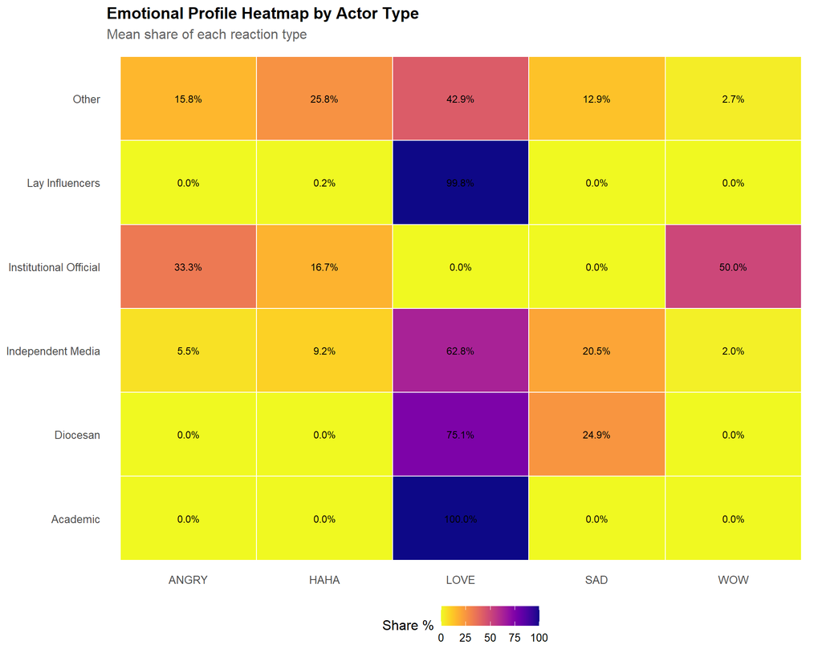

```r
if (exists("actor_emotions") && nrow(actor_emotions) > 0) {
  actor_emotions_matrix <- actor_emotions %>%
    select(ACTOR_TYPE, LOVE, WOW, HAHA, SAD, ANGRY) %>%
    pivot_longer(cols = -ACTOR_TYPE, names_to = "Emotion", values_to = "Share")

  ggplot(actor_emotions_matrix, aes(x = Emotion, y = ACTOR_TYPE, fill = Share)) +
    geom_tile(color = "white", linewidth = 0.5) +
    geom_text(aes(label = sprintf("%.1f%%", Share)), size = 3) +
    scale_fill_viridis(option = "plasma", direction = -1) +
    labs(
      title = "Emotional Profile Heatmap by Actor Type",
      subtitle = "Mean share of each reaction type",
      x = NULL,
      y = NULL,
      fill = "Share %"
    ) +
    theme(
      axis.text.x = element_text(angle = 0, hjust = 0.5),
      panel.grid = element_blank()
    )
}
```

## 3.4 LOVE Ratio Analysis

LOVE reactions indicate deep appreciation and emotional connection. High LOVE share suggests content that resonates strongly with audience values and emotions.

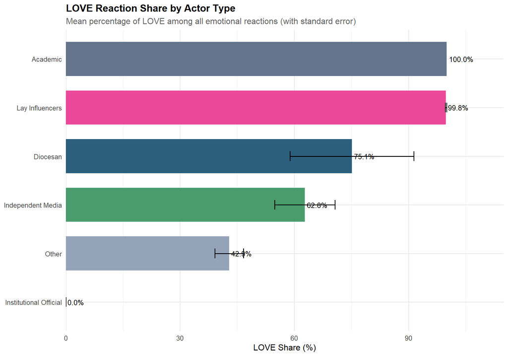

```r
if (nrow(fb_data) > 0 && sum(fb_data$Total_Reactions > 0, na.rm = TRUE) > 0) {
  love_by_actor <- fb_data[Total_Reactions > 0, .(
    Mean_Love_Share = mean(LOVE_SHARE, na.rm = TRUE) * 100,
    Median_Love_Share = median(LOVE_SHARE, na.rm = TRUE) * 100,
    SD_Love_Share = sd(LOVE_SHARE, na.rm = TRUE) * 100,
    Posts = .N
  ), by = ACTOR_TYPE][order(-Mean_Love_Share)]

  ggplot(love_by_actor, aes(x = reorder(ACTOR_TYPE, Mean_Love_Share),
                            y = Mean_Love_Share, fill = ACTOR_TYPE)) +
    geom_col(width = 0.7) +
    geom_errorbar(aes(ymin = Mean_Love_Share - SD_Love_Share/sqrt(Posts),
                      ymax = Mean_Love_Share + SD_Love_Share/sqrt(Posts)),
                  width = 0.2) +
    geom_text(aes(label = sprintf("%.1f%%", Mean_Love_Share)), hjust = -0.1, size = 3.5) +
    coord_flip() +
    scale_fill_manual(values = actor_colors) +
    scale_y_continuous(expand = expansion(mult = c(0, 0.15))) +
    labs(
      title = "LOVE Reaction Share by Actor Type",
      subtitle = "Mean percentage of LOVE among all emotional reactions (with standard error)",
      x = NULL,
      y = "LOVE Share (%)"
    ) +
    theme(legend.position = "none")
}
```

## 3.5 ANGRY Ratio Analysis

ANGRY reactions signal disagreement, outrage, or frustration. High ANGRY share may indicate controversial content, provocative framing, or topics that elicit strong negative responses.

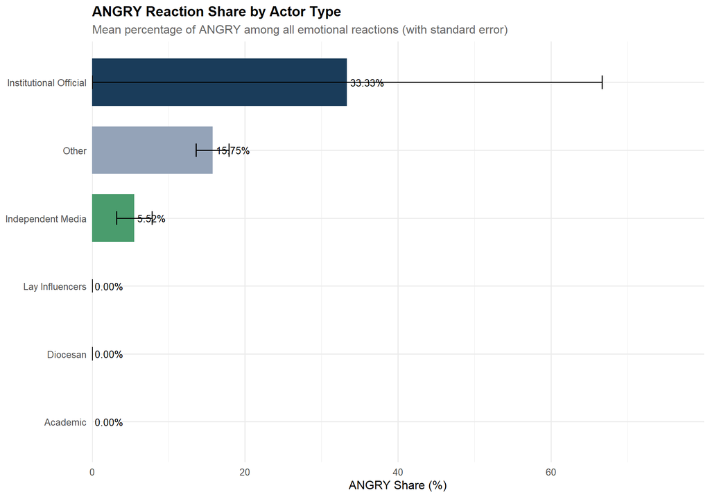

```r
if (nrow(fb_data) > 0 && sum(fb_data$Total_Reactions > 0, na.rm = TRUE) > 0) {
  angry_by_actor <- fb_data[Total_Reactions > 0, .(
    Mean_Angry_Share = mean(ANGRY_SHARE, na.rm = TRUE) * 100,
    Median_Angry_Share = median(ANGRY_SHARE, na.rm = TRUE) * 100,
    SD_Angry_Share = sd(ANGRY_SHARE, na.rm = TRUE) * 100,
    Posts = .N
  ), by = ACTOR_TYPE][order(-Mean_Angry_Share)]

  ggplot(angry_by_actor, aes(x = reorder(ACTOR_TYPE, Mean_Angry_Share),
                             y = Mean_Angry_Share, fill = ACTOR_TYPE)) +
    geom_col(width = 0.7) +
    geom_errorbar(aes(ymin = pmax(0, Mean_Angry_Share - SD_Angry_Share/sqrt(Posts)),
                      ymax = Mean_Angry_Share + SD_Angry_Share/sqrt(Posts)),
                  width = 0.2) +
    geom_text(aes(label = sprintf("%.2f%%", Mean_Angry_Share)), hjust = -0.1, size = 3.5) +
    coord_flip() +
    scale_fill_manual(values = actor_colors) +
    scale_y_continuous(expand = expansion(mult = c(0, 0.2))) +
    labs(
      title = "ANGRY Reaction Share by Actor Type",
      subtitle = "Mean percentage of ANGRY among all emotional reactions (with standard error)",
      x = NULL,
      y = "ANGRY Share (%)"
    ) +
    theme(legend.position = "none")
}
```

## 3.6 Emotional Profile Table

```r
if (exists("actor_emotions") && nrow(actor_emotions) > 0) {
  actor_emotions %>%
    mutate(
      Posts = format(Posts, big.mark = ","),
      LOVE = sprintf("%.1f%%", LOVE),
      WOW = sprintf("%.1f%%", WOW),
      HAHA = sprintf("%.1f%%", HAHA),
      SAD = sprintf("%.1f%%", SAD),
      ANGRY = sprintf("%.1f%%", ANGRY)
    ) %>%
    arrange(desc(as.numeric(gsub("%", "", LOVE)))) %>%
    kable(col.names = c("Actor Type", "LOVE", "WOW", "HAHA", "SAD", "ANGRY", "Posts")) %>%
    kable_styling(bootstrap_options = c("striped", "hover"), full_width = FALSE)
}
```

| Actor Type | LOVE | WOW | HAHA | SAD | ANGRY | Posts |
| --- | --- | --- | --- | --- | --- | --- |
| Academic | 100.0% | 0.0% | 0.0% | 0.0% | 0.0% | 1 |
| Lay Influencers | 99.8% | 0.0% | 0.2% | 0.0% | 0.0% | 21 |
| Diocesan | 75.1% | 0.0% | 0.0% | 24.9% | 0.0% | 8 |
| Independent Media | 62.8% | 2.0% | 9.2% | 20.5% | 5.5% | 32 |
| Other | 42.9% | 2.7% | 25.8% | 12.9% | 15.8% | 137 |
| Institutional Official | 0.0% | 50.0% | 16.7% | 0.0% | 33.3% | 2 |

# 4 Analysis 3.3: Controversy Detection

Controversy is operationalized through the **Controversy Index**, which combines the intensity of angry reactions with the visibility of the content.

**Formula:** `Controversy Index = (ANGRY_COUNT / INTERACTIONS) × log(INTERACTIONS + 1)`

This formula ensures that: 1. Content with higher ANGRY ratios scores higher 2. Content with more total interactions (greater reach) scores higher 3. The logarithmic transformation prevents extremely viral posts from dominating

Posts above the 95th percentile threshold are flagged as **controversial**.

```r
if (nrow(fb_data) > 0) {
  fb_data[, Controversy_Index := (fifelse(is.na(ANGRY_COUNT), 0, ANGRY_COUNT) / (INTERACTIONS + 1)) * log(INTERACTIONS + 1)]

  controversy_threshold <- quantile(fb_data$Controversy_Index, 0.95, na.rm = TRUE)
  fb_data[, Is_Controversial := Controversy_Index > controversy_threshold]

  cat("Controversy threshold (95th percentile):", round(controversy_threshold, 4), "\n")
  cat("Controversial posts:", sum(fb_data$Is_Controversial, na.rm = TRUE), "\n")
}
```

```
Controversy threshold (95th percentile): 0
Controversial posts: 71
```

## 4.1 Controversy Index Distribution

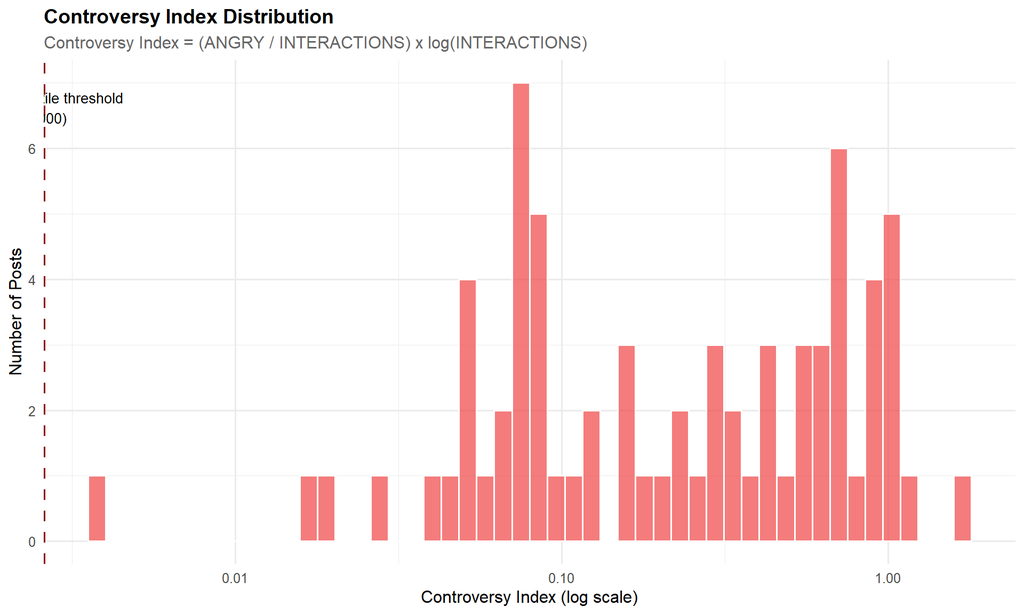

```r
if (nrow(fb_data) > 0 && sum(fb_data$Controversy_Index > 0, na.rm = TRUE) > 0) {
  ggplot(fb_data[Controversy_Index > 0], aes(x = Controversy_Index)) +
    geom_histogram(bins = 50, fill = "#ef4444", alpha = 0.7, color = "white") +
    geom_vline(xintercept = controversy_threshold, linetype = "dashed", color = "darkred", linewidth = 1) +
    annotate("text", x = controversy_threshold * 1.5, y = Inf, vjust = 2,
             label = sprintf("95th percentile threshold\n(%.3f)", controversy_threshold),
             size = 3.5) +
    scale_x_log10() +
    scale_y_continuous(labels = comma) +
    labs(
      title = "Controversy Index Distribution",
      subtitle = "Controversy Index = (ANGRY / INTERACTIONS) x log(INTERACTIONS)",
      x = "Controversy Index (log scale)",
      y = "Number of Posts"
    )
}
```

## 4.2 Most Controversial Posts

**Click to expand** (Top 20 most controversial posts)**

```r
if (nrow(fb_data) > 0) {
  top_controversial <- fb_data[order(-Controversy_Index)][1:min(50, nrow(fb_data)), .(
    Rank = .I,
    FROM,
    ACTOR_TYPE,
    DATE,
    TITLE_SHORT = substr(TITLE, 1, 60),
    INTERACTIONS,
    ANGRY_COUNT,
    Controversy_Index
  )]

  top_controversial[1:min(20, nrow(top_controversial))] %>%
    mutate(
      INTERACTIONS = format(INTERACTIONS, big.mark = ","),
      Controversy_Index = sprintf("%.3f", Controversy_Index)
    ) %>%
    kable(col.names = c("Rank", "Source", "Actor Type", "Date", "Title",
                        "Interactions", "ANGRY", "Index")) %>%
    kable_styling(bootstrap_options = c("striped", "hover"), full_width = FALSE) %>%
    scroll_box(height = "500px")
}
```

[output not shown]

## 4.3 Controversy by Actor Type

Which actor types produce the most controversial content on average?

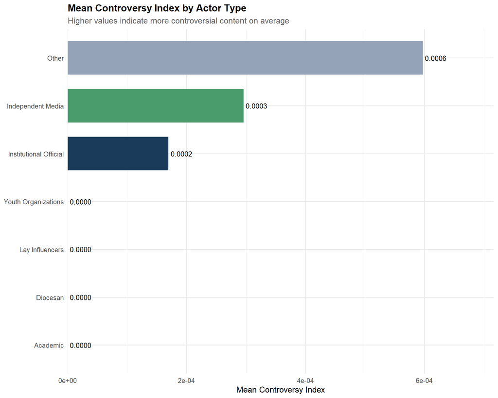

```r
if (nrow(fb_data) > 0) {
  controversy_actor <- fb_data[, .(
    Mean_Controversy = mean(Controversy_Index, na.rm = TRUE),
    Median_Controversy = median(Controversy_Index, na.rm = TRUE),
    Max_Controversy = max(Controversy_Index, na.rm = TRUE),
    Controversial_Posts = sum(Is_Controversial, na.rm = TRUE),
    Total_Posts = .N,
    Controversy_Rate = sum(Is_Controversial, na.rm = TRUE) / .N * 100
  ), by = ACTOR_TYPE][order(-Mean_Controversy)]

  ggplot(controversy_actor, aes(x = reorder(ACTOR_TYPE, Mean_Controversy),
                                 y = Mean_Controversy, fill = ACTOR_TYPE)) +
    geom_col(width = 0.7) +
    geom_text(aes(label = sprintf("%.4f", Mean_Controversy)), hjust = -0.1, size = 3.5) +
    coord_flip() +
    scale_fill_manual(values = actor_colors) +
    scale_y_continuous(expand = expansion(mult = c(0, 0.2))) +
    labs(
      title = "Mean Controversy Index by Actor Type",
      subtitle = "Higher values indicate more controversial content on average",
      x = NULL,
      y = "Mean Controversy Index"
    ) +
    theme(legend.position = "none")
}
```

## 4.4 Controversy Rate by Actor Type

The controversy rate shows the percentage of posts from each actor type that exceed the 95th percentile controversy threshold.

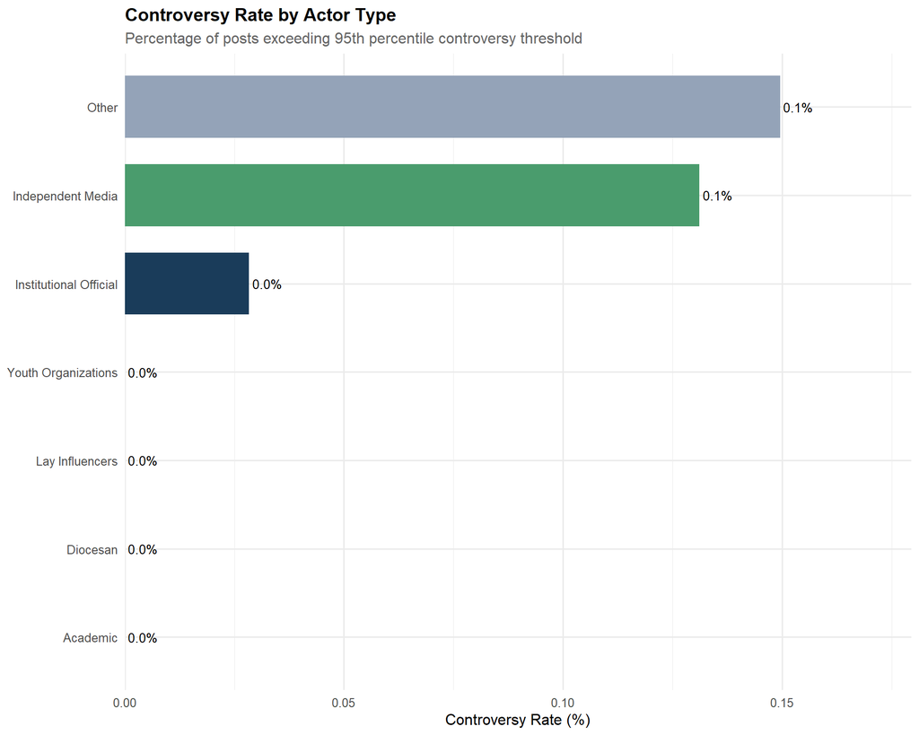

```r
if (exists("controversy_actor") && nrow(controversy_actor) > 0) {
  ggplot(controversy_actor, aes(x = reorder(ACTOR_TYPE, Controversy_Rate),
                                 y = Controversy_Rate, fill = ACTOR_TYPE)) +
    geom_col(width = 0.7) +
    geom_text(aes(label = sprintf("%.1f%%", Controversy_Rate)), hjust = -0.1, size = 3.5) +
    coord_flip() +
    scale_fill_manual(values = actor_colors) +
    scale_y_continuous(expand = expansion(mult = c(0, 0.2))) +
    labs(
      title = "Controversy Rate by Actor Type",
      subtitle = "Percentage of posts exceeding 95th percentile controversy threshold",
      x = NULL,
      y = "Controversy Rate (%)"
    ) +
    theme(legend.position = "none")
}
```

## 4.5 Controversy Summary Table

```r
if (exists("controversy_actor") && nrow(controversy_actor) > 0) {
  controversy_actor %>%
    mutate(
      Total_Posts = format(Total_Posts, big.mark = ","),
      Controversial_Posts = format(Controversial_Posts, big.mark = ","),
      Mean_Controversy = sprintf("%.4f", Mean_Controversy),
      Median_Controversy = sprintf("%.4f", Median_Controversy),
      Max_Controversy = sprintf("%.3f", Max_Controversy),
      Controversy_Rate = sprintf("%.2f%%", Controversy_Rate)
    ) %>%
    select(ACTOR_TYPE, Total_Posts, Controversial_Posts, Controversy_Rate,
           Mean_Controversy, Median_Controversy, Max_Controversy) %>%
    kable(col.names = c("Actor Type", "Total Posts", "Controversial Posts",
                        "Controversy Rate", "Mean Index", "Median Index", "Max Index")) %>%
    kable_styling(bootstrap_options = c("striped", "hover"), full_width = FALSE)
}
```

| Actor Type | Total Posts | Controversial Posts | Controversy Rate | Mean Index | Median Index | Max Index |
| --- | --- | --- | --- | --- | --- | --- |
| Other | 42,121 | 63 | 0.15% | 0.0006 | 0.0000 | 1.687 |
| Independent Media | 5,336 | 7 | 0.13% | 0.0003 | 0.0000 | 0.677 |
| Institutional Official | 3,525 | 1 | 0.03% | 0.0002 | 0.0000 | 0.597 |
| Diocesan | 2,820 | 0 | 0.00% | 0.0000 | 0.0000 | 0.000 |
| Lay Influencers | 9,800 | 0 | 0.00% | 0.0000 | 0.0000 | 0.000 |
| Academic | 190 | 0 | 0.00% | 0.0000 | 0.0000 | 0.000 |
| Youth Organizations | 51 | 0 | 0.00% | 0.0000 | 0.0000 | 0.000 |

## 4.6 Controversy Over Time

Tracking controversy over time can reveal periods of heightened conflict or tension in the Catholic digital space.

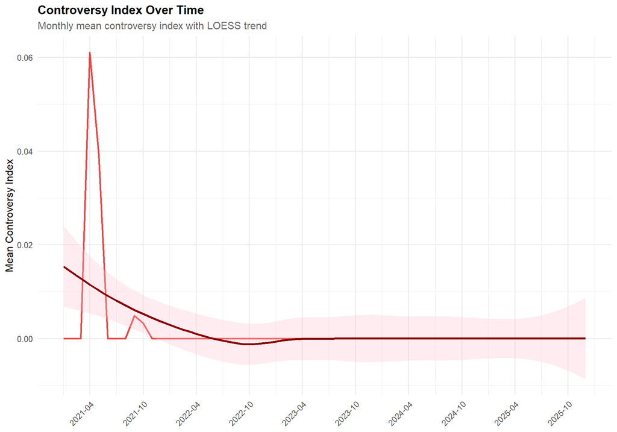

```r
if (nrow(fb_data) > 0) {
  controversy_time <- fb_data[, .(
    Mean_Controversy = mean(Controversy_Index, na.rm = TRUE),
    Controversial_Posts = sum(Is_Controversial, na.rm = TRUE),
    Total_Posts = .N
  ), by = .(Year = year(DATE), Month = month(DATE))]

  controversy_time[, Date := as.Date(paste(Year, Month, "01", sep = "-"))]
  controversy_time[, Controversy_Rate := Controversial_Posts / Total_Posts * 100]

  ggplot(controversy_time[!is.na(Date)], aes(x = Date, y = Mean_Controversy)) +
    geom_line(color = "#ef4444", linewidth = 1) +
    geom_smooth(method = "loess", se = TRUE, color = "darkred", fill = "pink", alpha = 0.3) +
    scale_x_date(date_labels = "%Y-%m", date_breaks = "6 months") +
    labs(
      title = "Controversy Index Over Time",
      subtitle = "Monthly mean controversy index with LOESS trend",
      x = NULL,
      y = "Mean Controversy Index"
    ) +
    theme(axis.text.x = element_text(angle = 45, hjust = 1))
}
```

## 4.7 Top Controversial Sources

**Click to expand** (Sources with highest mean controversy, minimum 20 posts)**

```r
if (nrow(fb_data) > 0) {
  source_controversy <- fb_data[, .(
    Mean_Controversy = mean(Controversy_Index, na.rm = TRUE),
    Max_Controversy = max(Controversy_Index, na.rm = TRUE),
    Controversial_Posts = sum(Is_Controversial, na.rm = TRUE),
    Total_Posts = .N,
    Total_ANGRY = sum(ANGRY_COUNT, na.rm = TRUE),
    ACTOR_TYPE = first(ACTOR_TYPE)
  ), by = FROM][Total_Posts >= 20][order(-Mean_Controversy)]

  if (nrow(source_controversy) > 0) {
    source_controversy[1:min(20, nrow(source_controversy))] %>%
      mutate(
        Total_Posts = format(Total_Posts, big.mark = ","),
        Total_ANGRY = format(Total_ANGRY, big.mark = ","),
        Mean_Controversy = sprintf("%.4f", Mean_Controversy),
        Max_Controversy = sprintf("%.3f", Max_Controversy)
      ) %>%
      select(FROM, ACTOR_TYPE, Total_Posts, Controversial_Posts,
             Mean_Controversy, Max_Controversy, Total_ANGRY) %>%
      kable(col.names = c("Source", "Actor Type", "Posts", "Controversial",
                          "Mean Index", "Max Index", "Total ANGRY")) %>%
      kable_styling(bootstrap_options = c("striped", "hover"), full_width = FALSE)
  }
}
```

| Source | Actor Type | Posts | Controversial | Mean Index | Max Index | Total ANGRY |
| --- | --- | --- | --- | --- | --- | --- |
| Nisam Vjernik | Other | 22 | 1 | 0.0445 | 0.979 | 17 |
| Makarska Danas | Other | 31 | 4 | 0.0187 | 0.409 | 10 |
| Index.hr | Other | 293 | 9 | 0.0136 | 1.011 | 301 |
| Jutarnji | Other | 262 | 5 | 0.0104 | 0.948 | 207 |
| Index Vijesti | Other | 240 | 2 | 0.0077 | 1.119 | 48 |
| Zoran Šprajc | Other | 22 | 1 | 0.0035 | 0.077 | 6 |
| Lupiga.com | Other | 47 | 1 | 0.0034 | 0.160 | 6 |
| Dalmatinski portal | Other | 239 | 1 | 0.0031 | 0.744 | 43 |
| 24sata | Other | 475 | 3 | 0.0026 | 0.695 | 74 |
| Narod.hr | Other | 465 | 2 | 0.0024 | 1.035 | 9 |
| Slobodna Dalmacija | Other | 764 | 5 | 0.0023 | 0.837 | 145 |
| Tportal.hr | Other | 408 | 3 | 0.0022 | 0.545 | 8 |
| N1 Hrvatska | Other | 326 | 1 | 0.0018 | 0.575 | 11 |
| Net.hr | Other | 655 | 2 | 0.0017 | 0.997 | 59 |
| DNEVNIK.hr | Other | 643 | 1 | 0.0016 | 1.052 | 47 |
| Dubrovački vjesnik | Other | 207 | 1 | 0.0016 | 0.322 | 1 |
| Dnevno.hr | Other | 620 | 4 | 0.0015 | 0.686 | 66 |
| SNAGA Šibenski portal | Other | 54 | 1 | 0.0013 | 0.072 | 1 |
| ŠibenikIN | Other | 459 | 1 | 0.0010 | 0.456 | 8 |
| Croative.net | Other | 350 | 1 | 0.0010 | 0.347 | 1 |

# 5 Analysis 3.4: Emotion by Sentiment

This section cross-tabulates automated sentiment classification with actual emotional reactions to validate whether sentiment labels align with audience responses.

**Expected patterns:** - Positive sentiment posts should receive more LOVE reactions - Negative sentiment posts should receive more ANGRY and SAD reactions - Neutral sentiment posts should show balanced emotional profiles

Deviations from these patterns may indicate limitations in the sentiment classifier or interesting disconnects between content tone and audience reception.

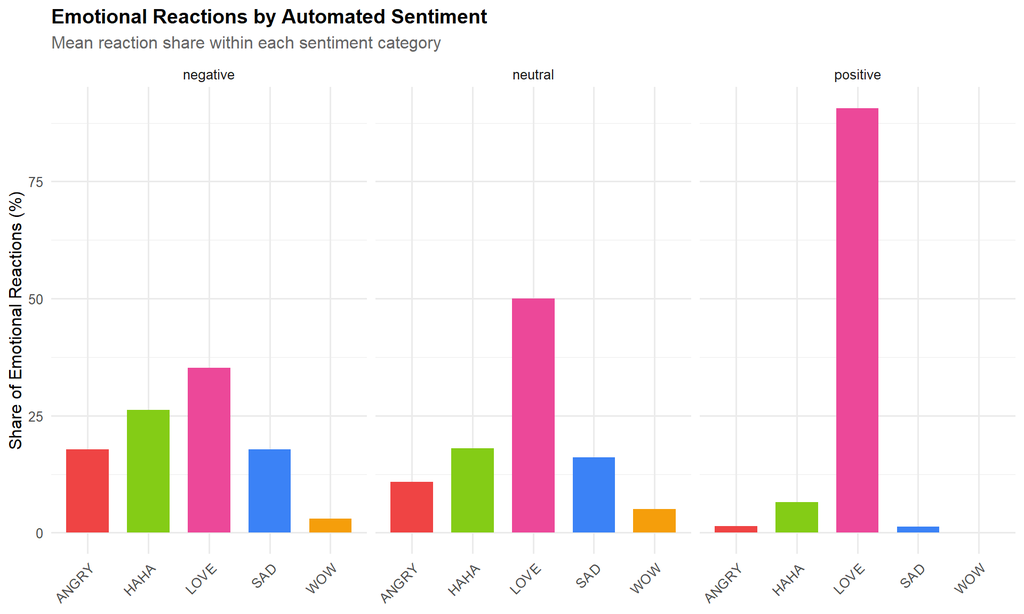

```r
if (nrow(fb_data) > 0 && sum(fb_data$Total_Reactions > 0, na.rm = TRUE) > 0) {
  emotion_sentiment <- fb_data[!is.na(AUTO_SENTIMENT) & Total_Reactions > 0, .(
    LOVE = mean(LOVE_SHARE, na.rm = TRUE) * 100,
    WOW = mean(WOW_SHARE, na.rm = TRUE) * 100,
    HAHA = mean(HAHA_SHARE, na.rm = TRUE) * 100,
    SAD = mean(SAD_SHARE, na.rm = TRUE) * 100,
    ANGRY = mean(ANGRY_SHARE, na.rm = TRUE) * 100,
    Posts = .N
  ), by = AUTO_SENTIMENT]

  emotion_sentiment_long <- emotion_sentiment %>%
    select(-Posts) %>%
    pivot_longer(cols = -AUTO_SENTIMENT, names_to = "Emotion", values_to = "Share")

  ggplot(emotion_sentiment_long, aes(x = Emotion, y = Share, fill = Emotion)) +
    geom_col(width = 0.7) +
    facet_wrap(~AUTO_SENTIMENT, ncol = 3) +
    scale_fill_manual(values = emotion_colors) +
    labs(
      title = "Emotional Reactions by Automated Sentiment",
      subtitle = "Mean reaction share within each sentiment category",
      x = NULL,
      y = "Share of Emotional Reactions (%)"
    ) +
    theme(
      legend.position = "none",
      axis.text.x = element_text(angle = 45, hjust = 1)
    )
}
```

## 5.1 Sentiment Validation Through Reactions

The **Positive Ratio** divides LOVE by (ANGRY + SAD) to measure whether sentiment classifications align with actual emotional responses. Higher ratios for positive sentiment validate the classifier.

```r
if (nrow(fb_data) > 0 && sum(fb_data$Total_Reactions > 0, na.rm = TRUE) > 0) {
  validation_metrics <- fb_data[!is.na(AUTO_SENTIMENT) & Total_Reactions > 0, .(
    Mean_Love = mean(LOVE_SHARE, na.rm = TRUE),
    Mean_Angry = mean(ANGRY_SHARE, na.rm = TRUE),
    Mean_Sad = mean(SAD_SHARE, na.rm = TRUE),
    Positive_Ratio = mean(LOVE_SHARE, na.rm = TRUE) / (mean(ANGRY_SHARE, na.rm = TRUE) + mean(SAD_SHARE, na.rm = TRUE) + 0.001)
  ), by = AUTO_SENTIMENT]

  validation_metrics %>%
    mutate(
      Mean_Love = sprintf("%.1f%%", Mean_Love * 100),
      Mean_Angry = sprintf("%.1f%%", Mean_Angry * 100),
      Mean_Sad = sprintf("%.1f%%", Mean_Sad * 100),
      Positive_Ratio = sprintf("%.2f", Positive_Ratio)
    ) %>%
    kable(col.names = c("Auto Sentiment", "Mean LOVE", "Mean ANGRY", "Mean SAD",
                        "Positive Ratio (LOVE / (ANGRY+SAD))")) %>%
    kable_styling(bootstrap_options = c("striped", "hover"), full_width = FALSE)
}
```

| Auto Sentiment | Mean LOVE | Mean ANGRY | Mean SAD | Positive Ratio (LOVE / (ANGRY+SAD)) |
| --- | --- | --- | --- | --- |
| negative | 35.2% | 17.9% | 17.7% | 0.99 |
| positive | 90.7% | 1.4% | 1.3% | 32.34 |
| neutral | 50.0% | 10.9% | 16.1% | 1.85 |

# 6 Analysis 3.5: Emotional Temporal Patterns

Emotional patterns may vary over time due to seasonal factors (liturgical calendar), events (elections, scandals), or longer term trends in the Catholic digital space.

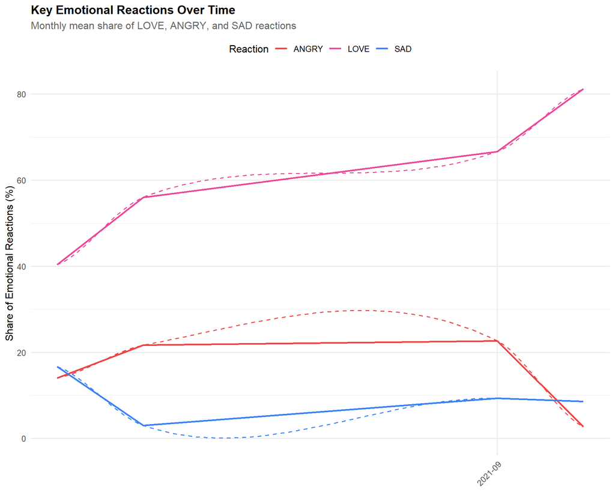

```r
if (nrow(fb_data) > 0 && sum(fb_data$Total_Reactions > 0, na.rm = TRUE) > 0) {
  emotion_monthly <- fb_data[Total_Reactions > 0, .(
    LOVE = mean(LOVE_SHARE, na.rm = TRUE) * 100,
    ANGRY = mean(ANGRY_SHARE, na.rm = TRUE) * 100,
    SAD = mean(SAD_SHARE, na.rm = TRUE) * 100,
    Posts = .N
  ), by = .(Year = year(DATE), Month = month(DATE))]

  emotion_monthly[, Date := as.Date(paste(Year, Month, "01", sep = "-"))]

  emotion_monthly_long <- emotion_monthly %>%
    select(Date, LOVE, ANGRY, SAD) %>%
    pivot_longer(cols = -Date, names_to = "Emotion", values_to = "Share")

  ggplot(emotion_monthly_long[!is.na(Date)], aes(x = Date, y = Share, color = Emotion)) +
    geom_line(linewidth = 1) +
    geom_smooth(method = "loess", se = FALSE, linetype = "dashed", linewidth = 0.7) +
    scale_color_manual(values = c("LOVE" = "#ec4899", "ANGRY" = "#ef4444", "SAD" = "#3b82f6")) +
    scale_x_date(date_labels = "%Y-%m", date_breaks = "6 months") +
    labs(
      title = "Key Emotional Reactions Over Time",
      subtitle = "Monthly mean share of LOVE, ANGRY, and SAD reactions",
      x = NULL,
      y = "Share of Emotional Reactions (%)",
      color = "Reaction"
    ) +
    theme(
      axis.text.x = element_text(angle = 45, hjust = 1),
      legend.position = "top"
    )
}
```

## 6.1 Day of Week Emotional Patterns

Do posting patterns by day of week affect emotional responses? Sunday posts (liturgical content) may receive different reactions than weekday posts.

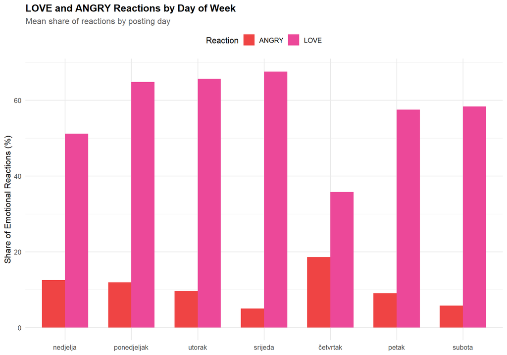

```r
if (nrow(fb_data) > 0 && sum(fb_data$Total_Reactions > 0, na.rm = TRUE) > 0) {
  fb_data[, DOW := lubridate::wday(DATE, label = TRUE, abbr = FALSE)]

  emotion_dow <- fb_data[Total_Reactions > 0 & !is.na(DOW), .(
    LOVE = mean(LOVE_SHARE, na.rm = TRUE) * 100,
    ANGRY = mean(ANGRY_SHARE, na.rm = TRUE) * 100,
    Posts = .N
  ), by = DOW]

  emotion_dow_long <- emotion_dow %>%
    select(DOW, LOVE, ANGRY) %>%
    pivot_longer(cols = -DOW, names_to = "Emotion", values_to = "Share")

  ggplot(emotion_dow_long, aes(x = DOW, y = Share, fill = Emotion)) +
    geom_col(position = "dodge", width = 0.7) +
    scale_fill_manual(values = c("LOVE" = "#ec4899", "ANGRY" = "#ef4444")) +
    labs(
      title = "LOVE and ANGRY Reactions by Day of Week",
      subtitle = "Mean share of reactions by posting day",
      x = NULL,
      y = "Share of Emotional Reactions (%)",
      fill = "Reaction"
    ) +
    theme(legend.position = "top")
}
```

# 7 Summary and Key Findings

```r
total_with_sentiment <- sum(!is.na(dta$AUTO_SENTIMENT))
positive_pct <- sum(dta$AUTO_SENTIMENT == "positive", na.rm = TRUE) / total_with_sentiment * 100
negative_pct <- sum(dta$AUTO_SENTIMENT == "negative", na.rm = TRUE) / total_with_sentiment * 100

fb_total <- nrow(fb_data)
mean_love_share <- if(fb_total > 0) mean(fb_data$LOVE_SHARE, na.rm = TRUE) * 100 else 0
mean_angry_share <- if(fb_total > 0) mean(fb_data$ANGRY_SHARE, na.rm = TRUE) * 100 else 0
controversial_count <- if(fb_total > 0) sum(fb_data$Is_Controversial, na.rm = TRUE) else 0
```

## 7.1 Summary Table

```r
tibble(
  Finding = c(
    "Total posts with sentiment data",
    "Positive sentiment share",
    "Negative sentiment share",
    "Facebook posts with reaction data",
    "Mean LOVE share of reactions",
    "Mean ANGRY share of reactions",
    "Posts exceeding controversy threshold"
  ),
  Value = c(
    format(total_with_sentiment, big.mark = ","),
    sprintf("%.1f%%", positive_pct),
    sprintf("%.1f%%", negative_pct),
    format(fb_total, big.mark = ","),
    sprintf("%.1f%%", mean_love_share),
    sprintf("%.2f%%", mean_angry_share),
    format(controversial_count, big.mark = ",")
  )
) %>%
  kable(col.names = c("Finding", "Value")) %>%
  kable_styling(bootstrap_options = c("striped", "hover"), full_width = FALSE)
```

| Finding | Value |
| --- | --- |
| Total posts with sentiment data | 608,879 |
| Positive sentiment share | 47.3% |
| Negative sentiment share | 28.7% |
| Facebook posts with reaction data | 63,843 |
| Mean LOVE share of reactions | 53.1% |
| Mean ANGRY share of reactions | 11.95% |
| Posts exceeding controversy threshold | 71 |

## 7.2 Hypotheses Testing Summary

| Hypothesis | Metric to Examine | Finding |
| --- | --- | --- |
| H10: Catholic digital content is predominantly positive | Sentiment distribution, positivity ratio | See overall sentiment distribution |
| H11: Lay influencers have highest LOVE ratios | LOVE share by actor type | Compare actor emotional fingerprints |
| H12: Independent media generates most controversy | Controversy rate by actor type | Compare controversy rates |
| H13: Negative sentiment correlates with higher engagement | Sentiment-engagement relationship | See sentiment-engagement analysis |

# 8 Appendix: Classification Quality Diagnostics

**Click to expand diagnostics** (Quality assurance for actor classification)**

```r
# Actor type distribution check
actor_dist <- dta[, .(
  Posts = .N,
  Sources = uniqueN(FROM),
  Mean_Interactions = mean(INTERACTIONS, na.rm = TRUE)
), by = ACTOR_TYPE][order(-Posts)]

actor_dist %>%
  mutate(
    Posts = format(Posts, big.mark = ","),
    Sources = format(Sources, big.mark = ","),
    Mean_Interactions = round(Mean_Interactions, 1)
  ) %>%
  kable(col.names = c("Actor Type", "Posts", "Sources", "Mean Interactions"),
        caption = "Actor Type Distribution in Emotional Analysis Sample") %>%
  kable_styling(bootstrap_options = c("striped", "hover"), full_width = FALSE)
```

Actor Type Distribution in Emotional Analysis Sample

| Actor Type | Posts | Sources | Mean Interactions |
| --- | --- | --- | --- |
| Other | 468,760 | 16,076 | 99.1 |
| Institutional Official | 62,744 | 202 | 56.6 |
| Independent Media | 31,401 | 18 | 210.2 |
| Lay Influencers | 28,451 | 62 | 224.7 |
| Diocesan | 13,841 | 50 | 46.0 |
| Religious Orders | 1,677 | 11 | 22.8 |
| Charismatic Communities | 1,282 | 12 | 153.7 |
| Academic | 671 | 5 | 17.3 |
| Youth Organizations | 52 | 4 | 128.8 |

```r
# Check high-engagement sources in Other category
other_high_engagement <- dta[ACTOR_TYPE == "Other" & SOURCE_TYPE == "facebook", .(
  Posts = .N,
  Total_Interactions = sum(INTERACTIONS, na.rm = TRUE)
), by = FROM][order(-Total_Interactions)][1:15]

other_high_engagement %>%
  mutate(
    Posts = format(Posts, big.mark = ","),
    Total_Interactions = format(Total_Interactions, big.mark = ",")
  ) %>%
  kable(col.names = c("Source", "Posts", "Total Interactions"),
        caption = "Top Facebook Sources in 'Other' Category (review for misclassification)") %>%
  kable_styling(bootstrap_options = c("striped", "hover"), full_width = FALSE)
```

Top Facebook Sources in 'Other' Category (review for misclassification)

| Source | Posts | Total Interactions |
| --- | --- | --- |
| Index.hr | 294 | 197,104 |
| Gospa | 624 | 179,812 |
| 24sata | 482 | 174,369 |
| DNEVNIK.hr | 648 | 164,778 |
| RTL Danas | 663 | 158,676 |
| Kraljica Mira | 1,224 | 155,621 |
| Velimir Bujanec | 114 | 144,769 |
| Net.hr | 664 | 135,958 |
| RTL Direkt | 157 | 135,282 |
| Marko Perković Thompson | 28 | 124,277 |
| Slobodna Dalmacija | 774 | 118,415 |
| Večernji list | 560 | 115,060 |
| Telegram.hr | 260 | 111,267 |
| Ivan Pokupec | 120 | 108,174 |
| HRT Vijesti | 180 | 106,376 |

# 9 Appendix: Model Diagnostics

```r
cat("Emotional Analysis Summary:\n")
```

```
Emotional Analysis Summary:
```

```r
cat("Total posts:", nrow(dta), "\n")
```

```
Total posts: 608879
```

```r
cat("Posts with sentiment:", sum(!is.na(dta$AUTO_SENTIMENT)), "\n")
```

```
Posts with sentiment: 608879
```

```r
cat("Facebook posts with reactions:", nrow(fb_data), "\n")
```

```
Facebook posts with reactions: 63843
```

```r
cat("Date range:", as.character(min(dta$DATE)), "to", as.character(max(dta$DATE)), "\n")
```

```
Date range: 2021-01-01 to 2025-12-31
```